# Project: Wrangling and Analyze Data

## Data Gathering

### Directly downloading the WeRateDogs Twitter archive data (twitter_archive_enhanced.csv)

*Importing the necessary libraries for the project*

```python
import pandas as pd
import numpy as np
import matplotlib.pyplot as plt
import datetime
import seaborn
import requests
import bs4
from bs4 import BeautifulSoup
import tweepy
from tweepy import OAuthHandler
import json
from timeit import default_timer as timer
import copy
```

```python
#Downloading and loading the "twitter_archive_enhanced.csv" directly
df_1 = pd.read_csv("twitter_archive_enhanced.csv")
```

### Using the Requests library to download the tweet image prediction (image_predictions.tsv)

```python
url = " https://d17h27t6h515a5.cloudfront.net/topher/2017/August/599fd2ad_image-predictions/image-predictions.tsv"
response = requests.get(url)
#Saving to File
with open("image-predictions.tsv", mode="wb") as file:
    file.write(response.content)
```

```python
#Creating a dataframe "df_2" using the downloaded file
df_2 = pd.read_csv("image-predictions.tsv", sep='\t')
```

### Using the Tweepy library to query additional data via the Twitter API (tweet_json.txt)

# Querying the Twitter API for each tweet in the Twitter archive and save JSON in a text file

# These are hidden to comply with Twitter's API terms and conditions

# df_1 is a DataFrame with the twitter_archive_enhanced.csv file.

# NOTE TO REVIEWER: this student had mobile verification issues so the following

# Twitter API code was sent to this student from a Udacity instructor

# Tweet IDs for which to gather additional data via Twitter's API

# Query Twitter's API for JSON data for each tweet ID in the Twitter archive

# Save each tweet's returned JSON as a new line in a .txt file

```
# This loop will likely take 20-30 minutes to run because of Twitter's rate limit
for tweet_id in tweet_ids:
    count += 1
    print(str(count) + ": " + str(tweet_id))
    try:
        tweet = api.get_status(tweet_id, tweet_mode='extended')
        print("Success")
        json.dump(tweet._json, outfile)
        outfile.write('\n')
    except tweepy.TweepError as e:
        print("Fail")
        fails_dict[tweet_id] = e
        pass
```

```python
#Forming a dataframe with the "tweet_json.txt" file
with open("tweet_json.txt") as f:
    lines = f.readlines()
df_list = []
for line in lines:
    df_list.append(json.loads(line))
df_new = pd.DataFrame(df_list)
```

```python
#Filtering the dataframe to form a dataframe with the needed columns
df_3 = df_new.filter(["id", "created_at", "favorite_count", "retweet_count"], axis=1)
```

## ASSESSING

```python
#Loading few lines from the dataframe "df_1"
df_1.head()
```

|  | tweet_id | in_reply_to_status_id | in_reply_to_user_id | timestamp | source | text | retweeted_status_id | retweeted_status_user_id | retweeted_status_timestamp | expanded_urls | rating_numerator | rating_denominator | name | doggo | floofer | pupper | puppo |
| --- | --- | --- | --- | --- | --- | --- | --- | --- | --- | --- | --- | --- | --- | --- | --- | --- | --- |
| 0 | 892420643555336193 | NaN | NaN | 2017-08-01 16:23:56 +0000 | <a href="http://twitter.com/download/iphone" r... | This is Phineas. He's a mystical boy. Only eve... | NaN | NaN | NaN | https://twitter.com/dog_rates/status/892420643... | 13 | 10 | Phineas | None | None | None | None |
| 1 | 892177421306343426 | NaN | NaN | 2017-08-01 00:17:27 +0000 | <a href="http://twitter.com/download/iphone" r... | This is Tilly. She's just checking pup on you.... | NaN | NaN | NaN | https://twitter.com/dog_rates/status/892177421... | 13 | 10 | Tilly | None | None | None | None |
| 2 | 891815181378084864 | NaN | NaN | 2017-07-31 00:18:03 +0000 | <a href="http://twitter.com/download/iphone" r... | This is Archie. He is a rare Norwegian Pouncin... | NaN | NaN | NaN | https://twitter.com/dog_rates/status/891815181... | 12 | 10 | Archie | None | None | None | None |
| 3 | 891689557279858688 | NaN | NaN | 2017-07-30 15:58:51 +0000 | <a href="http://twitter.com/download/iphone" r... | This is Darla. She commenced a snooze mid meal... | NaN | NaN | NaN | https://twitter.com/dog_rates/status/891689557... | 13 | 10 | Darla | None | None | None | None |
| 4 | 891327558926688256 | NaN | NaN | 2017-07-29 16:00:24 +0000 | <a href="http://twitter.com/download/iphone" r... | This is Franklin. He would like you to stop ca... | NaN | NaN | NaN | https://twitter.com/dog_rates/status/891327558... | 12 | 10 | Franklin | None | None | None | None |

```python
#Getting information about df_1
df_1.info()
```

```
<class 'pandas.core.frame.DataFrame'>
RangeIndex: 2356 entries, 0 to 2355
Data columns (total 17 columns):
tweet_id                      2356 non-null int64
in_reply_to_status_id         78 non-null float64
in_reply_to_user_id           78 non-null float64
timestamp                     2356 non-null object
source                        2356 non-null object
text                          2356 non-null object
retweeted_status_id           181 non-null float64
retweeted_status_user_id      181 non-null float64
retweeted_status_timestamp    181 non-null object
expanded_urls                 2297 non-null object
rating_numerator              2356 non-null int64
rating_denominator            2356 non-null int64
name                          2356 non-null object
doggo                         2356 non-null object
floofer                       2356 non-null object
pupper                        2356 non-null object
puppo                         2356 non-null object
dtypes: float64(4), int64(3), object(10)
memory usage: 313.0+ KB
```

```python
#Getting the shape of the dataset
df_1.shape
```

```
(2356, 17)
```

```python
#Getting the full description of the dataset
df_1.describe()
```

|  | tweet_id | in_reply_to_status_id | in_reply_to_user_id | retweeted_status_id | retweeted_status_user_id | rating_numerator | rating_denominator |
| --- | --- | --- | --- | --- | --- | --- | --- |
| count | 2.356000e+03 | 7.800000e+01 | 7.800000e+01 | 1.810000e+02 | 1.810000e+02 | 2356.000000 | 2356.000000 |
| mean | 7.427716e+17 | 7.455079e+17 | 2.014171e+16 | 7.720400e+17 | 1.241698e+16 | 13.126486 | 10.455433 |
| std | 6.856705e+16 | 7.582492e+16 | 1.252797e+17 | 6.236928e+16 | 9.599254e+16 | 45.876648 | 6.745237 |
| min | 6.660209e+17 | 6.658147e+17 | 1.185634e+07 | 6.661041e+17 | 7.832140e+05 | 0.000000 | 0.000000 |
| 25% | 6.783989e+17 | 6.757419e+17 | 3.086374e+08 | 7.186315e+17 | 4.196984e+09 | 10.000000 | 10.000000 |
| 50% | 7.196279e+17 | 7.038708e+17 | 4.196984e+09 | 7.804657e+17 | 4.196984e+09 | 11.000000 | 10.000000 |
| 75% | 7.993373e+17 | 8.257804e+17 | 4.196984e+09 | 8.203146e+17 | 4.196984e+09 | 12.000000 | 10.000000 |
| max | 8.924206e+17 | 8.862664e+17 | 8.405479e+17 | 8.874740e+17 | 7.874618e+17 | 1776.000000 | 170.000000 |

```python
#Getting the value counts of the column "rating_numerator"
df_1.rating_numerator.value_counts()
```

```
12      558
11      464
10      461
13      351
9       158
8       102
7        55
14       54
5        37
6        32
3        19
4        17
1         9
2         9
420       2
```

[output cut: 26 more lines]

```python
#Getting the value count of the column "rating_denominator"
df_1.rating_denominator.value_counts()
```

```
10     2333
11        3
50        3
80        2
20        2
2         1
16        1
40        1
70        1
15        1
90        1
110       1
120       1
130       1
150       1
170       1
7         1
0         1
Name: rating_denominator, dtype: int64
```

```python
#Sorting the timestamp to check if the date goes beyond "2017-08-01"
df_1.timestamp.sort_values()
```

```
2355    2015-11-15 22:32:08 +0000
2354    2015-11-15 23:05:30 +0000
2353    2015-11-15 23:21:54 +0000
2352    2015-11-16 00:04:52 +0000
2351    2015-11-16 00:24:50 +0000
2350    2015-11-16 00:30:50 +0000
2349    2015-11-16 00:35:11 +0000
2348    2015-11-16 00:49:46 +0000
2347    2015-11-16 00:55:59 +0000
2346    2015-11-16 01:01:59 +0000
2345    2015-11-16 01:22:45 +0000
2344    2015-11-16 01:52:02 +0000
2343    2015-11-16 01:59:36 +0000
2342    2015-11-16 02:38:37 +0000
2341    2015-11-16 03:22:39 +0000
```

[output cut: 47 more lines]

```python
#Getting the list of columns in the dataset
list(df_1)
```

```
['tweet_id',
 'in_reply_to_status_id',
 'in_reply_to_user_id',
 'timestamp',
 'source',
 'text',
 'retweeted_status_id',
 'retweeted_status_user_id',
 'retweeted_status_timestamp',
 'expanded_urls',
 'rating_numerator',
 'rating_denominator',
 'name',
 'doggo',
 'floofer',
 'pupper',
 'puppo']
```

```python
#Checking the sum of null null cells in each columns
df_1.isnull().sum()
```

```
tweet_id                         0
in_reply_to_status_id         2278
in_reply_to_user_id           2278
timestamp                        0
source                           0
text                             0
retweeted_status_id           2175
retweeted_status_user_id      2175
retweeted_status_timestamp    2175
expanded_urls                   59
rating_numerator                 0
rating_denominator               0
name                             0
doggo                            0
floofer                          0
pupper                           0
puppo                            0
dtype: int64
```

```python
#Checking for duplicates
df_1.duplicated().sum()
```

```
0
```

```python
#Accessing the value counts of the "name" column
df_1.name.value_counts()
```

```
None        745
a            55
Charlie      12
Cooper       11
Oliver       11
Lucy         11
Lola         10
Tucker       10
Penny        10
Winston       9
Bo            9
Sadie         8
the           8
an            7
Buddy         7
Bailey        7
Daisy         7
Toby          7
Dave          6
Rusty         6
Koda          6
Oscar         6
Scout         6
Leo           6
Jack          6
Milo          6
Jax           6
Bella         6
Stanley       6
Chester       5
           ...
Socks         1
Sid           1
Aubie         1
Colin         1
Georgie       1
Vinnie        1
Lolo          1
Gòrdón        1
Vinscent      1
Harry         1
Venti         1
Marq          1
Antony        1
Clyde         1
Daniel        1
Ziva          1
Acro          1
Travis        1
Gin           1
Sailer        1
Tycho         1
Laela         1
Ozzie         1
Murphy        1
Creg          1
Raphael       1
Noosh         1
Humphrey      1
Major         1
Einstein      1
Name: name, Length: 957, dtype: int64
```

```python
for text in df_1["text"]:
    print(text)
```

[output not shown]

[output cut: 2462 more lines]

```
This appears to be a Mongolian Presbyterian mix. Very tired. Tongue slip confirmed. 9/10 would lie down with https://t.co/mnioXo3IfP
Here we have a well-established sunblockerspaniel. Lost his other flip-flop. 6/10 not very waterproof https://t.co/3RU6x0vHB7
Let's hope this flight isn't Malaysian (lol). What a dog! Almost completely camouflaged. 10/10 I trust this pilot https://t.co/Yk6GHE9tOY
Here we have a northern speckled Rhododendron. Much sass. Gives 0 fucks. Good tongue. 9/10 would caress sensually https://t.co/ZoL8kq2XFx
This is the happiest dog you will ever see. Very committed owner. Nice couch. 10/10 https://t.co/RhUEAloehK
Here is the Rand Paul of retrievers folks! He's probably good at poker. Can drink beer (lol rad). 8/10 good dog https://t.co/pYAJkAe76p
My oh my. This is a rare blond Canadian terrier on wheels. Only $8.98. Rather docile. 9/10 very rare https://t.co/yWBqbrzy8O
Here is a Siberian heavily armored polar bear mix. Strong owner. 10/10 I would do unspeakable things to pet this dog https://t.co/rdivxLiqEt
This is an odd dog. Hard on the outside but loving on the inside. Petting still fun. Doesn't play catch well. 2/10 https://t.co/v5A4vzSDdc
This is a truly beautiful English Wilson Staff retriever. Has a nice phone. Privileged. 10/10 would trade lives with https://t.co/fvIbQfHjIe
Here we have a 1949 1st generation vulpix. Enjoys sweat tea and Fox News. Cannot be phased. 5/10 https://t.co/4B7cOc1EDq
This is a purebred Piers Morgan. Loves to Netflix and chill. Always looks like he forgot to unplug the iron. 6/10 https://t.co/DWnyCjf2mx
Here is a very happy pup. Big fan of well-maintained decks. Just look at that tongue. 9/10 would cuddle af https://t.co/y671yMhoiR
This is a western brown Mitsubishi terrier. Upset about leaf. Actually 2 dogs here. 7/10 would walk the shit out of https://t.co/r7mOb2m0UI
Here we have a Japanese Irish Setter. Lost eye in Vietnam (?). Big fan of relaxing on stair. 8/10 would pet https://t.co/BLDqew2Ijj
```

#### Accessing the second dataset ("imgae_prediction")

```python
#Loading few lines from the dataset
df_2.head()
```

|  | tweet_id | jpg_url | img_num | p1 | p1_conf | p1_dog | p2 | p2_conf | p2_dog | p3 | p3_conf | p3_dog |
| --- | --- | --- | --- | --- | --- | --- | --- | --- | --- | --- | --- | --- |
| 0 | 666020888022790149 | https://pbs.twimg.com/media/CT4udn0WwAA0aMy.jpg | 1 | Welsh_springer_spaniel | 0.465074 | True | collie | 0.156665 | True | Shetland_sheepdog | 0.061428 | True |
| 1 | 666029285002620928 | https://pbs.twimg.com/media/CT42GRgUYAA5iDo.jpg | 1 | redbone | 0.506826 | True | miniature_pinscher | 0.074192 | True | Rhodesian_ridgeback | 0.072010 | True |
| 2 | 666033412701032449 | https://pbs.twimg.com/media/CT4521TWwAEvMyu.jpg | 1 | German_shepherd | 0.596461 | True | malinois | 0.138584 | True | bloodhound | 0.116197 | True |
| 3 | 666044226329800704 | https://pbs.twimg.com/media/CT5Dr8HUEAA-lEu.jpg | 1 | Rhodesian_ridgeback | 0.408143 | True | redbone | 0.360687 | True | miniature_pinscher | 0.222752 | True |
| 4 | 666049248165822465 | https://pbs.twimg.com/media/CT5IQmsXIAAKY4A.jpg | 1 | miniature_pinscher | 0.560311 | True | Rottweiler | 0.243682 | True | Doberman | 0.154629 | True |

```python
#Getting information about the dataset
df_2.info()
```

```
<class 'pandas.core.frame.DataFrame'>
RangeIndex: 2075 entries, 0 to 2074
Data columns (total 12 columns):
tweet_id    2075 non-null int64
jpg_url     2075 non-null object
img_num     2075 non-null int64
p1          2075 non-null object
p1_conf     2075 non-null float64
p1_dog      2075 non-null bool
p2          2075 non-null object
p2_conf     2075 non-null float64
p2_dog      2075 non-null bool
p3          2075 non-null object
p3_conf     2075 non-null float64
p3_dog      2075 non-null bool
dtypes: bool(3), float64(3), int64(2), object(4)
memory usage: 152.1+ KB
```

```python
#Checcking the shape of the dataset
df_2.shape
```

```
(2075, 12)
```

```python
#Getting the description of the dataset
df_2.describe()
```

|  | tweet_id | img_num | p1_conf | p2_conf | p3_conf |
| --- | --- | --- | --- | --- | --- |
| count | 2.075000e+03 | 2075.000000 | 2075.000000 | 2.075000e+03 | 2.075000e+03 |
| mean | 7.384514e+17 | 1.203855 | 0.594548 | 1.345886e-01 | 6.032417e-02 |
| std | 6.785203e+16 | 0.561875 | 0.271174 | 1.006657e-01 | 5.090593e-02 |
| min | 6.660209e+17 | 1.000000 | 0.044333 | 1.011300e-08 | 1.740170e-10 |
| 25% | 6.764835e+17 | 1.000000 | 0.364412 | 5.388625e-02 | 1.622240e-02 |
| 50% | 7.119988e+17 | 1.000000 | 0.588230 | 1.181810e-01 | 4.944380e-02 |
| 75% | 7.932034e+17 | 1.000000 | 0.843855 | 1.955655e-01 | 9.180755e-02 |
| max | 8.924206e+17 | 4.000000 | 1.000000 | 4.880140e-01 | 2.734190e-01 |

```python
#Getting the list of columns in the dataset
list(df_2)
```

```
['tweet_id',
 'jpg_url',
 'img_num',
 'p1',
 'p1_conf',
 'p1_dog',
 'p2',
 'p2_conf',
 'p2_dog',
 'p3',
 'p3_conf',
 'p3_dog']
```

```python
#Checking for null cells in each of the columns
df_2.isnull().sum()
```

```
tweet_id    0
jpg_url     0
img_num     0
p1          0
p1_conf     0
p1_dog      0
p2          0
p2_conf     0
p2_dog      0
p3          0
p3_conf     0
p3_dog      0
dtype: int64
```

```python
#Checking for duplicates
df_2.duplicated().sum()
```

```
0
```

#### Accessing the dataset df_3 (from Twitter API JSON file)

```python
#Loading few lines from the dataset
df_3.head()
```

|  | id | created_at | favorite_count | retweet_count |
| --- | --- | --- | --- | --- |
| 0 | 892420643555336193 | Tue Aug 01 16:23:56 +0000 2017 | 33712 | 6975 |
| 1 | 892177421306343426 | Tue Aug 01 00:17:27 +0000 2017 | 29238 | 5276 |
| 2 | 891815181378084864 | Mon Jul 31 00:18:03 +0000 2017 | 21982 | 3466 |
| 3 | 891689557279858688 | Sun Jul 30 15:58:51 +0000 2017 | 36811 | 7197 |
| 4 | 891327558926688256 | Sat Jul 29 16:00:24 +0000 2017 | 35195 | 7721 |

```python
#Getting information about the various columns of the dataset
df_3.info()
```

```
<class 'pandas.core.frame.DataFrame'>
RangeIndex: 2327 entries, 0 to 2326
Data columns (total 4 columns):
id                2327 non-null int64
created_at        2327 non-null object
favorite_count    2327 non-null int64
retweet_count     2327 non-null int64
dtypes: int64(3), object(1)
memory usage: 72.8+ KB
```

```python
#Sorting the date column to ensuring its not beyond "2017-08-01"
df_3.created_at.sort_values()
```

```
1181    Fri Apr 01 00:26:15 +0000 2016
1180    Fri Apr 01 00:58:13 +0000 2016
1179    Fri Apr 01 02:51:22 +0000 2016
1178    Fri Apr 01 04:30:16 +0000 2016
1177    Fri Apr 01 15:46:52 +0000 2016
208     Fri Apr 07 00:38:06 +0000 2017
207     Fri Apr 07 13:04:55 +0000 2017
206     Fri Apr 07 16:10:12 +0000 2017
1162    Fri Apr 08 00:30:51 +0000 2016
1161    Fri Apr 08 01:19:36 +0000 2016
1160    Fri Apr 08 15:05:29 +0000 2016
1159    Fri Apr 08 15:26:28 +0000 2016
1158    Fri Apr 08 20:46:50 +0000 2016
196     Fri Apr 14 15:51:39 +0000 2017
195     Fri Apr 14 17:27:40 +0000 2017
```

[output cut: 47 more lines]

```python
#Getting the shape of the dataset
df_3.shape
```

```
(2327, 4)
```

```python
#Getting the description of the dataset
df_3.describe()
```

|  | id | favorite_count | retweet_count |
| --- | --- | --- | --- |
| count | 2.327000e+03 | 2327.000000 | 2327.000000 |
| mean | 7.417930e+17 | 7030.568543 | 2460.240653 |
| std | 6.820795e+16 | 10925.377346 | 4166.560910 |
| min | 6.660209e+17 | 0.000000 | 1.000000 |
| 25% | 6.781394e+17 | 1221.000000 | 492.500000 |
| 50% | 7.178418e+17 | 3038.000000 | 1144.000000 |
| 75% | 7.986547e+17 | 8570.000000 | 2846.000000 |
| max | 8.924206e+17 | 144338.000000 | 70382.000000 |

```python
#Getting the list of columns in the dataset
list(df_3)
```

```
['id', 'created_at', 'favorite_count', 'retweet_count']
```

```python
#Checking for null cells in the various columns
df_3.isnull().sum()
```

```
id                0
created_at        0
favorite_count    0
retweet_count     0
dtype: int64
```

```python
#Checking for duplicates
df_3.duplicated().sum()
```

```
0
```

### OBSERVED QUALITY AND TIDINESS ISSUES WITH THE VARIOUS DATASETS

### Quality issues

> 1. The dataset df_1 contains retweet data in some of its columns (in_reply_to_status_id, in_reply_to_user_id, retweeted_status_id, retweeted_status_user_id, retweeted_status_timestamp, expanded_urls).
> 2. Wrong datatype for the column "timestamp" in df_1 (given as "object" instead of "datetime").
> 3. Wrong datatype for the column "created_at" in df_3" (given as 'object' instead of 'datetime').
> 4. Date created is given as "created_as" and "timestamp" in df_3 and df_1 respectively. This is same record having different column name.
> 5. The time "created_at" and "timestamp" in df_3 and df_1 respectively contains an invalid timezone.
> 6. df_3 has the column "id" instead of tweet_id.
> 7. df_2 column labels contains abbreviated names.
> 8. The rating_numerator and rating_denominator in df_1 contains erroneous values.

### Tidiness issues

> 1. The column "tweet_id" is contained in the 3 datasets (df_1, df_2, df_3)
> 2. The "timestamp"(created_at) is also contained in 2 dataframes (df_1 and df_3)

## Cleaning Data

```python
# Making copies of the original pieces of data
df1_clean = df_1.copy()
df2_clean = df_2.copy()
df3_clean = df_3.copy()
```

### ISSUE #1

#### Define:

Retweets are not to be considered. Removing columns having retweet information (in_reply_to_status_id, in_reply_to_user_id, retweeted_status_id, retweeted_status_user_id, retweeted_status_timestamp, expanded_urls) in df_1.

#### Code

```python
df1_clean.head()
```

|  | tweet_id | in_reply_to_status_id | in_reply_to_user_id | timestamp | source | text | retweeted_status_id | retweeted_status_user_id | retweeted_status_timestamp | expanded_urls | rating_numerator | rating_denominator | name | doggo | floofer | pupper | puppo |
| --- | --- | --- | --- | --- | --- | --- | --- | --- | --- | --- | --- | --- | --- | --- | --- | --- | --- |
| 0 | 892420643555336193 | NaN | NaN | 2017-08-01 16:23:56 +0000 | <a href="http://twitter.com/download/iphone" r... | This is Phineas. He's a mystical boy. Only eve... | NaN | NaN | NaN | https://twitter.com/dog_rates/status/892420643... | 13 | 10 | Phineas | None | None | None | None |
| 1 | 892177421306343426 | NaN | NaN | 2017-08-01 00:17:27 +0000 | <a href="http://twitter.com/download/iphone" r... | This is Tilly. She's just checking pup on you.... | NaN | NaN | NaN | https://twitter.com/dog_rates/status/892177421... | 13 | 10 | Tilly | None | None | None | None |
| 2 | 891815181378084864 | NaN | NaN | 2017-07-31 00:18:03 +0000 | <a href="http://twitter.com/download/iphone" r... | This is Archie. He is a rare Norwegian Pouncin... | NaN | NaN | NaN | https://twitter.com/dog_rates/status/891815181... | 12 | 10 | Archie | None | None | None | None |
| 3 | 891689557279858688 | NaN | NaN | 2017-07-30 15:58:51 +0000 | <a href="http://twitter.com/download/iphone" r... | This is Darla. She commenced a snooze mid meal... | NaN | NaN | NaN | https://twitter.com/dog_rates/status/891689557... | 13 | 10 | Darla | None | None | None | None |
| 4 | 891327558926688256 | NaN | NaN | 2017-07-29 16:00:24 +0000 | <a href="http://twitter.com/download/iphone" r... | This is Franklin. He would like you to stop ca... | NaN | NaN | NaN | https://twitter.com/dog_rates/status/891327558... | 12 | 10 | Franklin | None | None | None | None |

```python
#Dropping the columns with retweet and reply informations in "df1_clean"
df1_clean = df1_clean.drop(["in_reply_to_status_id", "in_reply_to_user_id", "retweeted_status_id", "retweeted_status_user_id", "retweeted_status_timestamp", "expanded_urls"], axis=1)
```

```python
#Dropping non-original tweets which are reply and retweet using the identifier "@", which signifies that the tweet is a response and not an original tweet
df1_clean = df1_clean[df1_clean["text"].str.contains("@") == False]
```

#### Test

```python
df1_clean.head()
```

|  | tweet_id | timestamp | source | text | rating_numerator | rating_denominator | name | doggo | floofer | pupper | puppo |
| --- | --- | --- | --- | --- | --- | --- | --- | --- | --- | --- | --- |
| 0 | 892420643555336193 | 2017-08-01 16:23:56 +0000 | <a href="http://twitter.com/download/iphone" r... | This is Phineas. He's a mystical boy. Only eve... | 13 | 10 | Phineas | None | None | None | None |
| 1 | 892177421306343426 | 2017-08-01 00:17:27 +0000 | <a href="http://twitter.com/download/iphone" r... | This is Tilly. She's just checking pup on you.... | 13 | 10 | Tilly | None | None | None | None |
| 2 | 891815181378084864 | 2017-07-31 00:18:03 +0000 | <a href="http://twitter.com/download/iphone" r... | This is Archie. He is a rare Norwegian Pouncin... | 12 | 10 | Archie | None | None | None | None |
| 3 | 891689557279858688 | 2017-07-30 15:58:51 +0000 | <a href="http://twitter.com/download/iphone" r... | This is Darla. She commenced a snooze mid meal... | 13 | 10 | Darla | None | None | None | None |
| 4 | 891327558926688256 | 2017-07-29 16:00:24 +0000 | <a href="http://twitter.com/download/iphone" r... | This is Franklin. He would like you to stop ca... | 12 | 10 | Franklin | None | None | None | None |

### Issue #2:

#### Define:

Changing the datatype of the column "timestamp" in df_1, from "object" to "datetime"

#### Code

```python
df1_clean["timestamp"] = pd.to_datetime(df1_clean["timestamp"])
```

#### Test

```python
df1_clean.info()
```

```
<class 'pandas.core.frame.DataFrame'>
Int64Index: 2089 entries, 0 to 2355
Data columns (total 11 columns):
tweet_id              2089 non-null int64
timestamp             2089 non-null datetime64[ns]
source                2089 non-null object
text                  2089 non-null object
rating_numerator      2089 non-null int64
rating_denominator    2089 non-null int64
name                  2089 non-null object
doggo                 2089 non-null object
floofer               2089 non-null object
pupper                2089 non-null object
puppo                 2089 non-null object
dtypes: datetime64[ns](1), int64(3), object(7)
memory usage: 195.8+ KB
```

### ISSUE #3

#### Define:

Changing the datatype of the column "created_at" in df_3, from "object" to "datetime"

#### Code

```python
df3_clean["created_at"] = pd.to_datetime(df3_clean["created_at"])
```

#### Test

```python
df3_clean.info()
```

```
<class 'pandas.core.frame.DataFrame'>
RangeIndex: 2327 entries, 0 to 2326
Data columns (total 4 columns):
id                2327 non-null int64
created_at        2327 non-null datetime64[ns]
favorite_count    2327 non-null int64
retweet_count     2327 non-null int64
dtypes: datetime64[ns](1), int64(3)
memory usage: 72.8 KB
```

### ISSUE #4:

#### Define:

Date created is given as "created_as" and "timestamp" in df3_clean and df1_clean respectively. This is same record having different column name. Therefore, the column names need to be renamed as "date_created" to ensure consistency.

#### Code

```python
#Renaming the "timestamp" culumn in df1_clean
df1_clean.rename(columns = {"timestamp" : "date_created"}, inplace=True)
#Renaming the "created_at" column in df3_clean
df3_clean.rename(columns = {"created_at" : "date_created"}, inplace=True)
```

#### Test

```python
list(df1_clean)
```

```
['tweet_id',
 'date_created',
 'source',
 'text',
 'rating_numerator',
 'rating_denominator',
 'name',
 'doggo',
 'floofer',
 'pupper',
 'puppo']
```

```python
list(df3_clean)
```

```
['id', 'date_created', 'favorite_count', 'retweet_count']
```

### ISSUE #5:

#### Define:

Removing the invalid timezone contained in "timestamp" and "created_columns" in df1_clean and df3_clean respectively

#### Code:

> This has already been taken care of when the datatype was converted from "object" to "datetime"

#### Test

```python
#Loading few lines from the dataframe
df1_clean.head()
```

|  | tweet_id | date_created | source | text | rating_numerator | rating_denominator | name | doggo | floofer | pupper | puppo |
| --- | --- | --- | --- | --- | --- | --- | --- | --- | --- | --- | --- |
| 0 | 892420643555336193 | 2017-08-01 16:23:56 | <a href="http://twitter.com/download/iphone" r... | This is Phineas. He's a mystical boy. Only eve... | 13 | 10 | Phineas | None | None | None | None |
| 1 | 892177421306343426 | 2017-08-01 00:17:27 | <a href="http://twitter.com/download/iphone" r... | This is Tilly. She's just checking pup on you.... | 13 | 10 | Tilly | None | None | None | None |
| 2 | 891815181378084864 | 2017-07-31 00:18:03 | <a href="http://twitter.com/download/iphone" r... | This is Archie. He is a rare Norwegian Pouncin... | 12 | 10 | Archie | None | None | None | None |
| 3 | 891689557279858688 | 2017-07-30 15:58:51 | <a href="http://twitter.com/download/iphone" r... | This is Darla. She commenced a snooze mid meal... | 13 | 10 | Darla | None | None | None | None |
| 4 | 891327558926688256 | 2017-07-29 16:00:24 | <a href="http://twitter.com/download/iphone" r... | This is Franklin. He would like you to stop ca... | 12 | 10 | Franklin | None | None | None | None |

```python
#Loading few rows from the dataset
df3_clean.head()
```

|  | id | date_created | favorite_count | retweet_count |
| --- | --- | --- | --- | --- |
| 0 | 892420643555336193 | 2017-08-01 16:23:56 | 33712 | 6975 |
| 1 | 892177421306343426 | 2017-08-01 00:17:27 | 29238 | 5276 |
| 2 | 891815181378084864 | 2017-07-31 00:18:03 | 21982 | 3466 |
| 3 | 891689557279858688 | 2017-07-30 15:58:51 | 36811 | 7197 |
| 4 | 891327558926688256 | 2017-07-29 16:00:24 | 35195 | 7721 |

### ISSUE #6:

### Define:

Renaming the "id' column in df3_clean to "tweet_id' for comformity with similar columns in the oher dataframes.

#### Code

```python
#Renaming the column "id" to "tweet_id"
df3_clean.rename(columns = {"id" : "tweet_id"}, inplace=True)
```

#### Test

```python
df3_clean.head(0)
```

|  | tweet_id | date_created | favorite_count | retweet_count |
| --- | --- | --- | --- | --- |

### ISSUE #7:

#### Define:

Correcting the abrreviated column labels in df_2 with their full names. This includes p1, p1_conf, p1_dog etc

```python
df2_clean.head(0)
```

|  | tweet_id | jpg_url | img_num | p1 | p1_conf | p1_dog | p2 | p2_conf | p2_dog | p3 | p3_conf | p3_dog |
| --- | --- | --- | --- | --- | --- | --- | --- | --- | --- | --- | --- | --- |

```python
dict = {"img_num" : "image_number",
        "p1" : "prediction_1",
        "p1_conf" : "prediction_1_confidence",
        "p1_dog" : "prediction_1_dog",
        "p2" : "prediction_2",
        "p2_conf" : "prediction_2_confidence",
        "p2_dog" : "prediction_2_dog",
        "p3" : "prediction_3",
        "p3_conf" : "prediction_3_confidence",
        "p3_dog" : "prediction_3_dog"}

df2_clean.rename(columns=dict,
                 inplace=True)
```

#### Test

```python
df2_clean.head()
```

|  | tweet_id | jpg_url | image_number | prediction_1 | prediction_1_confidence | prediction_1_dog | prediction_2 | prediction_2_confidence | prediction_2_dog | prediction_3 | prediction_3_confidence | prediction_3_dog |
| --- | --- | --- | --- | --- | --- | --- | --- | --- | --- | --- | --- | --- |
| 0 | 666020888022790149 | https://pbs.twimg.com/media/CT4udn0WwAA0aMy.jpg | 1 | Welsh_springer_spaniel | 0.465074 | True | collie | 0.156665 | True | Shetland_sheepdog | 0.061428 | True |
| 1 | 666029285002620928 | https://pbs.twimg.com/media/CT42GRgUYAA5iDo.jpg | 1 | redbone | 0.506826 | True | miniature_pinscher | 0.074192 | True | Rhodesian_ridgeback | 0.072010 | True |
| 2 | 666033412701032449 | https://pbs.twimg.com/media/CT4521TWwAEvMyu.jpg | 1 | German_shepherd | 0.596461 | True | malinois | 0.138584 | True | bloodhound | 0.116197 | True |
| 3 | 666044226329800704 | https://pbs.twimg.com/media/CT5Dr8HUEAA-lEu.jpg | 1 | Rhodesian_ridgeback | 0.408143 | True | redbone | 0.360687 | True | miniature_pinscher | 0.222752 | True |
| 4 | 666049248165822465 | https://pbs.twimg.com/media/CT5IQmsXIAAKY4A.jpg | 1 | miniature_pinscher | 0.560311 | True | Rottweiler | 0.243682 | True | Doberman | 0.154629 | True |

### ISSUE #8

#### Define:

Correcting the wrong rating_numerator and rating_denominator in df1_clean. This will be done by replacing numerator outliers (ratings less than 1 and greater than 15) with the mean "rating_numerator" i.e (13), and replacing the denominator outliers ( less than or greater tan 10) with the mean rating_denominator i.e 10.

#### Code

```python
#Checking the value count of rating numerator
df1_clean.rating_numerator.value_counts()
```

```
12      475
10      433
11      411
13      286
9       156
8        96
7        54
14       38
5        35
6        32
3        18
4        16
2         9
1         8
0         2
```

[output cut: 21 more lines]

```python
#Checking the value count of rating denominator
df1_clean.rating_denominator.value_counts()
```

```
10     2069
50        3
11        2
80        2
20        2
7         1
170       1
150       1
130       1
120       1
110       1
90        1
70        1
40        1
16        1
2         1
Name: rating_denominator, dtype: int64
```

```python
#Replacing the numerator outlier values
for x in df1_clean.index:
    if df1_clean.loc[x, "rating_numerator"] > 15 or df1_clean.loc[x, "rating_numerator"] < 1:
        df1_clean.loc[x, "rating_numerator"] = 13
```

```python
#Replacing the denominator outlier values
for x in df1_clean.index:
    if df1_clean.loc[x, "rating_denominator"] > 10 or df1_clean.loc[x, "rating_denominator"] < 10:
        df1_clean.loc[x, "rating_denominator"] = 10
```

```python
#creating a column "rating" that is the division of rating_numerator by rating_denominator
df1_clean["rating"] = df1_clean["rating_numerator"] / df1_clean["rating_denominator"]
```

#### Test

```python
df1_clean.rating_numerator.value_counts()
```

```
12    475
10    433
11    411
13    308
9     156
8      96
7      54
14     38
5      35
6      32
3      18
4      16
2       9
1       8
Name: rating_numerator, dtype: int64
```

```python
df1_clean.rating_denominator.value_counts()
```

```
10    2089
Name: rating_denominator, dtype: int64
```

```python
list(df1_clean)
```

```
['tweet_id',
 'date_created',
 'source',
 'text',
 'rating_numerator',
 'rating_denominator',
 'name',
 'doggo',
 'floofer',
 'pupper',
 'puppo',
 'rating']
```

```python
df1_clean.head()
```

|  | tweet_id | date_created | source | text | rating_numerator | rating_denominator | name | doggo | floofer | pupper | puppo | rating |
| --- | --- | --- | --- | --- | --- | --- | --- | --- | --- | --- | --- | --- |
| 0 | 892420643555336193 | 2017-08-01 16:23:56 | <a href="http://twitter.com/download/iphone" r... | This is Phineas. He's a mystical boy. Only eve... | 13 | 10 | Phineas | None | None | None | None | 1.3 |
| 1 | 892177421306343426 | 2017-08-01 00:17:27 | <a href="http://twitter.com/download/iphone" r... | This is Tilly. She's just checking pup on you.... | 13 | 10 | Tilly | None | None | None | None | 1.3 |
| 2 | 891815181378084864 | 2017-07-31 00:18:03 | <a href="http://twitter.com/download/iphone" r... | This is Archie. He is a rare Norwegian Pouncin... | 12 | 10 | Archie | None | None | None | None | 1.2 |
| 3 | 891689557279858688 | 2017-07-30 15:58:51 | <a href="http://twitter.com/download/iphone" r... | This is Darla. She commenced a snooze mid meal... | 13 | 10 | Darla | None | None | None | None | 1.3 |
| 4 | 891327558926688256 | 2017-07-29 16:00:24 | <a href="http://twitter.com/download/iphone" r... | This is Franklin. He would like you to stop ca... | 12 | 10 | Franklin | None | None | None | None | 1.2 |

### TIDINESS ISSUES

#### Code

```python
df_merge = pd.merge(df1_clean, df3_clean, on=["tweet_id", "date_created"], how="left")
```

#### Test

```python
df_merge.head()
```

|  | tweet_id | date_created | source | text | rating_numerator | rating_denominator | name | doggo | floofer | pupper | puppo | rating | favorite_count | retweet_count |
| --- | --- | --- | --- | --- | --- | --- | --- | --- | --- | --- | --- | --- | --- | --- |
| 0 | 892420643555336193 | 2017-08-01 16:23:56 | <a href="http://twitter.com/download/iphone" r... | This is Phineas. He's a mystical boy. Only eve... | 13 | 10 | Phineas | None | None | None | None | 1.3 | 33712.0 | 6975.0 |
| 1 | 892177421306343426 | 2017-08-01 00:17:27 | <a href="http://twitter.com/download/iphone" r... | This is Tilly. She's just checking pup on you.... | 13 | 10 | Tilly | None | None | None | None | 1.3 | 29238.0 | 5276.0 |
| 2 | 891815181378084864 | 2017-07-31 00:18:03 | <a href="http://twitter.com/download/iphone" r... | This is Archie. He is a rare Norwegian Pouncin... | 12 | 10 | Archie | None | None | None | None | 1.2 | 21982.0 | 3466.0 |
| 3 | 891689557279858688 | 2017-07-30 15:58:51 | <a href="http://twitter.com/download/iphone" r... | This is Darla. She commenced a snooze mid meal... | 13 | 10 | Darla | None | None | None | None | 1.3 | 36811.0 | 7197.0 |
| 4 | 891327558926688256 | 2017-07-29 16:00:24 | <a href="http://twitter.com/download/iphone" r... | This is Franklin. He would like you to stop ca... | 12 | 10 | Franklin | None | None | None | None | 1.2 | 35195.0 | 7721.0 |

### ISSUE #2

#### Code

```python
wrangle_act = pd.merge(df_merge, df2_clean, on="tweet_id", how="left")
```

#### Test

```python
wrangle_act.head()
```

|  | tweet_id | date_created | source | text | rating_numerator | rating_denominator | name | doggo | floofer | pupper | ... | image_number | prediction_1 | prediction_1_confidence | prediction_1_dog | prediction_2 | prediction_2_confidence | prediction_2_dog | prediction_3 | prediction_3_confidence | prediction_3_dog |
| --- | --- | --- | --- | --- | --- | --- | --- | --- | --- | --- | --- | --- | --- | --- | --- | --- | --- | --- | --- | --- | --- |
| 0 | 892420643555336193 | 2017-08-01 16:23:56 | <a href="http://twitter.com/download/iphone" r... | This is Phineas. He's a mystical boy. Only eve... | 13 | 10 | Phineas | None | None | None | ... | 1.0 | orange | 0.097049 | False | bagel | 0.085851 | False | banana | 0.076110 | False |
| 1 | 892177421306343426 | 2017-08-01 00:17:27 | <a href="http://twitter.com/download/iphone" r... | This is Tilly. She's just checking pup on you.... | 13 | 10 | Tilly | None | None | None | ... | 1.0 | Chihuahua | 0.323581 | True | Pekinese | 0.090647 | True | papillon | 0.068957 | True |
| 2 | 891815181378084864 | 2017-07-31 00:18:03 | <a href="http://twitter.com/download/iphone" r... | This is Archie. He is a rare Norwegian Pouncin... | 12 | 10 | Archie | None | None | None | ... | 1.0 | Chihuahua | 0.716012 | True | malamute | 0.078253 | True | kelpie | 0.031379 | True |
| 3 | 891689557279858688 | 2017-07-30 15:58:51 | <a href="http://twitter.com/download/iphone" r... | This is Darla. She commenced a snooze mid meal... | 13 | 10 | Darla | None | None | None | ... | 1.0 | paper_towel | 0.170278 | False | Labrador_retriever | 0.168086 | True | spatula | 0.040836 | False |
| 4 | 891327558926688256 | 2017-07-29 16:00:24 | <a href="http://twitter.com/download/iphone" r... | This is Franklin. He would like you to stop ca... | 12 | 10 | Franklin | None | None | None | ... | 2.0 | basset | 0.555712 | True | English_springer | 0.225770 | True | German_short-haired_pointer | 0.175219 | True |

5 rows × 25 columns

```python
wrangle_act.duplicated().sum()
```

```
0
```

```python
list(wrangle_act)
```

```
['tweet_id',
 'date_created',
 'source',
 'text',
 'rating_numerator',
 'rating_denominator',
 'name',
 'doggo',
 'floofer',
 'pupper',
 'puppo',
 'rating',
 'favorite_count',
 'retweet_count',
 'jpg_url',
 'image_number',
 'prediction_1',
 'prediction_1_confidence',
 'prediction_1_dog',
 'prediction_2',
 'prediction_2_confidence',
 'prediction_2_dog',
 'prediction_3',
 'prediction_3_confidence',
 'prediction_3_dog']
```

## Analyzing and Visualizing Data

```python
wrangle_act.favorite_count.value_counts().sort_index()
```

```
66.0        1
72.0        1
88.0        1
90.0        1
92.0        1
93.0        1
98.0        1
99.0        1
100.0       1
106.0       1
107.0       1
112.0       1
115.0       1
123.0       1
127.0       1
134.0       1
137.0       1
139.0       1
142.0       1
143.0       1
147.0       1
151.0       1
160.0       1
162.0       1
163.0       1
165.0       1
168.0       2
171.0       1
175.0       1
179.0       1
           ..
42891.0     1
43314.0     1
44418.0     1
46167.0     1
46448.0     1
46627.0     1
48468.0     1
49258.0     1
50170.0     1
53830.0     1
56688.0     1
57778.0     1
60001.0     1
62278.0     1
63046.0     1
66085.0     1
67065.0     1
69076.0     1
70358.0     1
70709.0     1
73240.0     1
73750.0     1
80336.0     1
82432.0     1
92551.0     1
106857.0    1
108556.0    1
111277.0    1
123739.0    1
144338.0    1
Name: favorite_count, Length: 1909, dtype: int64
```

```python
wrangle_act.retweet_count.value_counts().sort_index()
```

```
11.0       1
13.0       1
19.0       1
24.0       1
28.0       1
30.0       1
35.0       2
36.0       2
37.0       1
38.0       1
39.0       2
40.0       2
41.0       1
42.0       1
43.0       2
44.0       2
45.0       2
46.0       2
47.0       1
48.0       1
50.0       5
51.0       1
53.0       2
54.0       1
55.0       2
56.0       2
58.0       1
59.0       1
61.0       1
62.0       2
          ..
15689.0    1
15740.0    1
16084.0    1
16258.0    1
16308.0    1
16588.0    1
16837.0    1
16942.0    1
17734.0    1
19121.0    1
19200.0    1
19373.0    1
19629.0    1
19918.0    1
20685.0    1
21888.0    1
22670.0    1
25030.0    1
26186.0    1
26631.0    1
27668.0    1
28472.0    1
30075.0    1
32241.0    1
34438.0    1
37292.0    1
39792.0    1
51458.0    1
52672.0    1
70382.0    1
Name: retweet_count, Length: 1595, dtype: int64
```

```python
wrangle_act.rating.value_counts().sort_index()
```

```
0.1      8
0.2      9
0.3     18
0.4     16
0.5     35
0.6     32
0.7     54
0.8     96
0.9    156
1.0    433
1.1    411
1.2    475
1.3    308
1.4     38
Name: rating, dtype: int64
```

```python
wrangle_act.loc[wrangle_act["retweet_count"] > 30000]
```

|  | tweet_id | date_created | source | text | rating_numerator | rating_denominator | name | doggo | floofer | pupper | ... | image_number | prediction_1 | prediction_1_confidence | prediction_1_dog | prediction_2 | prediction_2_confidence | prediction_2_dog | prediction_3 | prediction_3_confidence | prediction_3_dog |
| --- | --- | --- | --- | --- | --- | --- | --- | --- | --- | --- | --- | --- | --- | --- | --- | --- | --- | --- | --- | --- | --- |
| 59 | 879415818425184262 | 2017-06-26 19:07:24 | <a href="http://twitter.com/download/iphone" r... | This is Duddles. He did an attempt. 13/10 some... | 13 | 10 | Duddles | None | None | None | ... | 1.0 | English_springer | 0.383404 | True | Boston_bull | 0.134967 | True | Cardigan | 0.110481 | True |
| 114 | 866450705531457537 | 2017-05-22 00:28:40 | <a href="http://twitter.com/download/iphone" r... | This is Jamesy. He gives a kiss to every other... | 13 | 10 | Jamesy | None | None | pupper | ... | 2.0 | French_bulldog | 0.905334 | True | Boston_bull | 0.078060 | True | pug | 0.001771 | True |
| 325 | 822872901745569793 | 2017-01-21 18:26:02 | <a href="http://twitter.com/download/iphone" r... | Here's a super supportive puppo participating ... | 13 | 10 | None | None | None | None | ... | 1.0 | Lakeland_terrier | 0.196015 | True | Labrador_retriever | 0.160329 | True | Irish_terrier | 0.069126 | True |
| 348 | 819004803107983360 | 2017-01-11 02:15:36 | <a href="http://twitter.com/download/iphone" r... | This is Bo. He was a very good First Doggo. 14... | 14 | 10 | Bo | doggo | None | None | ... | 1.0 | standard_poodle | 0.351308 | True | toy_poodle | 0.271929 | True | Tibetan_terrier | 0.094759 | True |
| 419 | 807106840509214720 | 2016-12-09 06:17:20 | <a href="http://twitter.com/download/iphone" r... | This is Stephan. He just wants to help. 13/10 ... | 13 | 10 | Stephan | None | None | None | ... | 1.0 | Chihuahua | 0.505370 | True | Pomeranian | 0.120358 | True | toy_terrier | 0.077008 | True |
| 421 | 806629075125202948 | 2016-12-07 22:38:52 | <a href="http://twitter.com/download/iphone" r... | "Good afternoon class today we're going to lea... | 13 | 10 | None | None | None | None | ... | 2.0 | Arabian_camel | 0.366248 | False | house_finch | 0.209852 | False | cocker_spaniel | 0.046403 | True |
| 821 | 744234799360020481 | 2016-06-18 18:26:18 | <a href="http://twitter.com/download/iphone" r... | Here's a doggo realizing you can stand in a po... | 13 | 10 | None | doggo | None | None | ... | 1.0 | Labrador_retriever | 0.825333 | True | ice_bear | 0.044681 | False | whippet | 0.018442 | True |
| 858 | 739238157791694849 | 2016-06-04 23:31:25 | <a href="http://twitter.com/download/iphone" r... | Here's a doggo blowing bubbles. It's downright... | 13 | 10 | None | doggo | None | None | ... | 1.0 | Eskimo_dog | 0.503372 | True | Siberian_husky | 0.390413 | True | malamute | 0.080901 | True |

8 rows × 25 columns

```python
wrangle_act.loc[wrangle_act["favorite_count"] > 90000]
```

|  | tweet_id | date_created | source | text | rating_numerator | rating_denominator | name | doggo | floofer | pupper | ... | image_number | prediction_1 | prediction_1_confidence | prediction_1_dog | prediction_2 | prediction_2_confidence | prediction_2_dog | prediction_3 | prediction_3_confidence | prediction_3_dog |
| --- | --- | --- | --- | --- | --- | --- | --- | --- | --- | --- | --- | --- | --- | --- | --- | --- | --- | --- | --- | --- | --- |
| 59 | 879415818425184262 | 2017-06-26 19:07:24 | <a href="http://twitter.com/download/iphone" r... | This is Duddles. He did an attempt. 13/10 some... | 13 | 10 | Duddles | None | None | None | ... | 1.0 | English_springer | 0.383404 | True | Boston_bull | 0.134967 | True | Cardigan | 0.110481 | True |
| 114 | 866450705531457537 | 2017-05-22 00:28:40 | <a href="http://twitter.com/download/iphone" r... | This is Jamesy. He gives a kiss to every other... | 13 | 10 | Jamesy | None | None | pupper | ... | 2.0 | French_bulldog | 0.905334 | True | Boston_bull | 0.078060 | True | pug | 0.001771 | True |
| 325 | 822872901745569793 | 2017-01-21 18:26:02 | <a href="http://twitter.com/download/iphone" r... | Here's a super supportive puppo participating ... | 13 | 10 | None | None | None | None | ... | 1.0 | Lakeland_terrier | 0.196015 | True | Labrador_retriever | 0.160329 | True | Irish_terrier | 0.069126 | True |
| 419 | 807106840509214720 | 2016-12-09 06:17:20 | <a href="http://twitter.com/download/iphone" r... | This is Stephan. He just wants to help. 13/10 ... | 13 | 10 | Stephan | None | None | None | ... | 1.0 | Chihuahua | 0.505370 | True | Pomeranian | 0.120358 | True | toy_terrier | 0.077008 | True |
| 821 | 744234799360020481 | 2016-06-18 18:26:18 | <a href="http://twitter.com/download/iphone" r... | Here's a doggo realizing you can stand in a po... | 13 | 10 | None | doggo | None | None | ... | 1.0 | Labrador_retriever | 0.825333 | True | ice_bear | 0.044681 | False | whippet | 0.018442 | True |
| 858 | 739238157791694849 | 2016-06-04 23:31:25 | <a href="http://twitter.com/download/iphone" r... | Here's a doggo blowing bubbles. It's downright... | 13 | 10 | None | doggo | None | None | ... | 1.0 | Eskimo_dog | 0.503372 | True | Siberian_husky | 0.390413 | True | malamute | 0.080901 | True |

6 rows × 25 columns

```python
wrangle_act.rating.value_counts()
```

```
1.2    475
1.0    433
1.1    411
1.3    308
0.9    156
0.8     96
0.7     54
1.4     38
0.5     35
0.6     32
0.3     18
0.4     16
0.2      9
0.1      8
Name: rating, dtype: int64
```

```python
wrangle_act.describe()
```

|  | tweet_id | rating_numerator | rating_denominator | rating | favorite_count | retweet_count | image_number | prediction_1_confidence | prediction_2_confidence | prediction_3_confidence |
| --- | --- | --- | --- | --- | --- | --- | --- | --- | --- | --- |
| count | 2.089000e+03 | 2089.000000 | 2089.0 | 2089.000000 | 2081.000000 | 2081.000000 | 1970.000000 | 1970.000000 | 1.970000e+03 | 1.970000e+03 |
| mean | 7.363254e+17 | 10.602202 | 10.0 | 1.060220 | 7745.535320 | 2285.456511 | 1.204569 | 0.594519 | 1.344090e-01 | 6.025797e-02 |
| std | 6.738721e+16 | 2.191549 | 0.0 | 0.219155 | 11309.753027 | 4030.092507 | 0.563202 | 0.272299 | 1.008058e-01 | 5.102189e-02 |
| min | 6.660209e+17 | 1.000000 | 10.0 | 0.100000 | 66.000000 | 11.000000 | 1.000000 | 0.044333 | 1.011300e-08 | 1.740170e-10 |
| 25% | 6.762636e+17 | 10.000000 | 10.0 | 1.000000 | 1663.000000 | 492.000000 | 1.000000 | 0.362857 | 5.351907e-02 | 1.606823e-02 |
| 50% | 7.091984e+17 | 11.000000 | 10.0 | 1.100000 | 3510.000000 | 1100.000000 | 1.000000 | 0.588620 | 1.175870e-01 | 4.947920e-02 |
| 75% | 7.881506e+17 | 12.000000 | 10.0 | 1.200000 | 9619.000000 | 2600.000000 | 1.000000 | 0.847216 | 1.955197e-01 | 9.159438e-02 |
| max | 8.924206e+17 | 14.000000 | 10.0 | 1.400000 | 144338.000000 | 70382.000000 | 4.000000 | 1.000000 | 4.880140e-01 | 2.734190e-01 |

### Insights:

> 1. tweets that has the highest retweet_counts also have the highest favorite_counts(likes). This can be proven from the correlation heatmap where the correlation index between retweet_count and favorite_count is 0.93. This is a near perfect correlation and demostrates the fact that, higher favorite_counts also corresponds to a higher retweet_counts.
> 2. The ratings are saturated close to the mean rating (1.06) with a standard deviation of 0.219. This shows us that the rating for each tweet are not too disperse from the other. In conclusin, most tweets are rated within a close rating margin.
> 3. No "favorite_count" and "retweet_count" is independent of the dog type, as no particular dog type dominates among the highest_rated retweet and favorites.
> 4. The correlation between the "rating" to the "favorite_count" and "retweet_count" is not too strong (0.38) and (0.29) respectively. This tells us that the rating given to any particular dog tweet does not directly affect the favorite and retweet counts of that tweet in a big way, rather, its a combianation of it and some other factors.

### Visualization

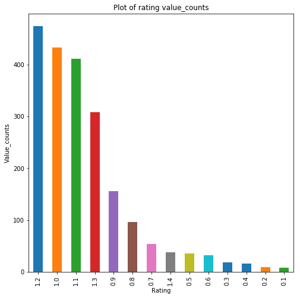

```python
#Bar plot of the value counts for the "rating"(rating_numerator divided by rating_denominator)
rating_plot = wrangle_act["rating"].value_counts()
rating_plot.plot(kind="bar", figsize=(8,8), title="Plot of rating value_counts")
plt.xlabel("Rating")
plt.ylabel("Value_counts");
```

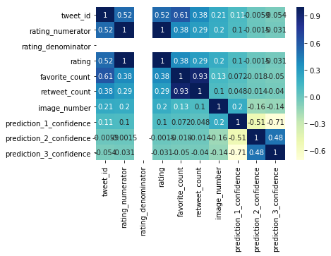

```python
#Heatmap of the correlation between variables in the dataframe
import seaborn as sns
sns.heatmap(wrangle_act.corr(), cmap="YlGnBu", annot=True);
```